# Machine Learning in the Social Sciences

Regularized regression

Christoph Kern

## Setup

```r
library(mlbench)
library(glmnet)
library(quanteda)
library(Matrix)
library(readxl)
library(dplyr)
library(lubridate)
library(caret)
```

## Data

```r
CLAS18 = read_excel("CLASSIFY_categ_comm_14-18_FINAL.xlsx",sheet="categ_comm_sub_14-18") %>%
         filter(nposts>1) %>% select(-nposts)
CLAS18
```

```r
set.seed(555)
mult = 10
s = sample(1:nrow(DTS), mult*sum(DTS$is_troll))
DTS$selected =FALSE
DTS$selected[DTS$is_troll]=TRUE
DTS$selected[s]=TRUE
```

Since we want to compare the performance of some regularized models at the end of the modeling process, we first split the data into a training and a test part. This can be done by random sampling with `sample`.

```r
DTSs = DTS %>% filter(selected) %>% left_join(CLAS18 %>% select(subreddit, categ1))
#write_rds(DTSs, "DTSs.rds", compress = "xz")
```

```r
REDDIT = read_rds("data/RedditExeter.rds")
REDDIT
```

| archived | author | created_utc | domain | is_self | link_flair_css_class | media_type | name | num_comments | over_18 | post_hint | score | selftext | stickied | subreddit | title | url | yt_author | yt_description | yt_title | datetime | date | hour | is_troll |
| --- | --- | --- | --- | --- | --- | --- | --- | --- | --- | --- | --- | --- | --- | --- | --- | --- | --- | --- | --- | --- | --- | --- | --- |
| FALSE | I-_I | 1464566925 | zerohedge.com | FALSE |  |  | t3_4lmz1q | 2 | FALSE | link | 40 |  | FALSE | altnewz | ""Bill Clinton Was Here"": The Elite One-Percent’s 'Orgy Island' Exposed | http://www.zerohedge.com/news/2016-05-29/bill-clinton-was-here-elite-one-percent%E2%80%99s-orgy-island-exposed |  |  |  | 2016-05-30 00:08:45 | 2016-05-30 | 0 | FALSE |
| FALSE | I-_I | 1464568978 | zerohedge.com | FALSE |  |  | t3_4ln3g4 | 0 | FALSE | link | 1 |  | FALSE | altnewz | UK To Stockpile Tanks, Heavy Equipment Close To Russia's Border | http://www.zerohedge.com/news/2016-05-29/uk-stockpile-tanks-heavy-equipment-close-russias-border |  |  |  | 2016-05-30 00:42:58 | 2016-05-30 | 0 | FALSE |
| FALSE | flyinghighernow | 1464572383 | whowhatwhy.org | FALSE |  |  | t3_4lnaz8 | 0 | FALSE | link | 5 |  | FALSE | altnewz | Are More Primary Problems Looming in California? | http://whowhatwhy.org/2016/05/28/primary-problems-looming-california/ |  |  |  | 2016-05-30 01:39:43 | 2016-05-30 | 1 | FALSE |
| FALSE | Kevin_Milner | 1464614929 | scitechnation.com | FALSE |  |  | t3_4lpiiq | 0 | FALSE | link | 0 |  | FALSE | altnewz | Barack Obama was sponsored by Russian opposition | http://scitechnation.com/obama-was-sponsored-by-russian-opposition/ |  |  |  | 2016-05-30 13:28:49 | 2016-05-30 | 13 | TRUE |
| FALSE | ShaunaDorothy | 1464634805 | i.imgur.com | FALSE |  |  | t3_4lr14r | 1 | FALSE | image | 7 |  | FALSE | altnewz | Clinton Makes Out - Bill's Excellent Adventure | http://i.imgur.com/t3EFSkX.png |  |  |  | 2016-05-30 19:00:05 | 2016-05-30 | 19 | FALSE |
| FALSE | flyinghighernow | 1464645205 | fair.org | FALSE |  |  | t3_4lru1b | 0 | FALSE | link | 34 |  | FALSE | altnewz | 538 Sacrifices Integrity to Go After Sanders on Independents | http://fair.org/home/538-sacrifices-integrity-to-go-after-sanders-on-independents/ |  |  |  | 2016-05-30 21:53:25 | 2016-05-30 | 21 | FALSE |
| FALSE | pheonix200 | 1464650838 | bigstory.ap.org | FALSE |  |  | t3_4ls8ne | 11 | FALSE | link | 17 |  | FALSE | altnewz | Physicist Stephen Hawking baffled by Donald Trump's rise | http://bigstory.ap.org/article/c562d36dc0ea4e9eb6e7cfe155e1a6c7/physicist-stephen-hawking-baffled-donald-trumps-rise |  |  |  | 2016-05-30 23:27:18 | 2016-05-30 | 23 | FALSE |
| FALSE | I-_I | 1464652656 | zerohedge.com | FALSE |  |  | t3_4lsd9c | 1 | FALSE |  | 9 |  | FALSE | altnewz | Electronic Voting Machines &amp; Why Voters Should Be Suspicious Of Every Election | http://www.zerohedge.com/news/2016-05-30/electronic-voting-machines-why-voters-should-be-suspicious-every-election |  |  |  | 2016-05-30 23:57:36 | 2016-05-30 | 23 | FALSE |
| FALSE | I-_I | 1464652764 | kunstler.com | FALSE |  |  | t3_4lsdiv | 0 | FALSE | link | 2 |  | FALSE | altnewz | The Fat Lady Always Sings Twice | http://kunstler.com/clusterfuck-nation/fat-lady-always-sings-twice/ |  |  |  | 2016-05-30 23:59:24 | 2016-05-30 | 23 | FALSE |
| FALSE | ruskeeblue | 1466055469 | upi.com | FALSE |  |  | t3_4obtw5 | 1 | FALSE | link | 2 |  | FALSE | altnewz | $40 billion aid package to Israel is 'largest ever' to any country, says Susan Rice | http://www.upi.com/Top_News/US/2016/06/14/40-billion-aid-to-Israel-is-largest-ever-to-any-country-says-Susan-Rice/5461465914964/ |  |  |  | 2016-06-16 05:37:49 | 2016-06-16 | 5 | FALSE |

[output cut: 990 more lines]

```r
R_corpus = corpus(REDDIT %>% transmute(name, num_comments, is_self, score, title, hour, is_troll),
               docid_field="name", text_field="title")
R_DFM = dfm(R_corpus,
            stem=TRUE,
            remove_punct = TRUE,
            remove = stopwords("english"),
            remove_numbers = TRUE)
R_DFM_trim = R_DFM %>% dfm_trim(min_docfreq = 50) %>% dfm_tfidf()
#dfmDTSm = convert(R_DFM_final, to = "data.frame") %>% select(-document) %>%
#          cbind(.,docvars(R_DFM_final)) %>%
#          mutate(is_troll = factor(is_troll), is_self = factor(is_self),
#                 categ1 = factor(categ1))
#names(dfmDTSm) = make.names(names(dfmDTSm))
R_DFM_final = R_DFM_trim %>% dfm_remove("document") %>%
              dfm_replace(featnames(R_DFM_trim), make.names(featnames(R_DFM_trim)))
```

```r
set.seed(7345)
train <- sample(1:nrow(R_DFM_final), 0.7*nrow(R_DFM_final))
reddit_train_X <- R_DFM_final[train,]
reddit_test_X <- R_DFM_final[-train,]
reddit_train_XM = convert(reddit_train_X, to = "matrix")
reddit_test_XM =  convert(reddit_test_X, to = "matrix")
reddit_train_Y = docvars(R_DFM_final)$is_troll[train] %>% factor(labels = c("not","TROLL"))
reddit_test_Y = docvars(R_DFM_final)$is_troll[-train] %>% factor(labels = c("not","TROLL"))
```

### Lasso

```r
m2 <- glmnet(reddit_train_X, reddit_train_Y, alpha = 1, family="binomial")
```

Here we want to display the first, last and one in-between model of our model series. We see that coefficients are eventually shrunken exactly to zero as the penalty on model complexity increases.

```r
m2$lambda[1]
m2$lambda[(ncol(m2$beta)/2)]
m2$lambda[ncol(m2$beta)]
m2$beta[,1]
m2$beta[,(ncol(m2$beta)/2)]
m2$beta[,ncol(m2$beta)]
```

[output not shown]

```r
plot(m2, label=T, xvar = "lambda")
```

[output not shown]

When using Cross-Validation with Lasso, we see that a full model with all features may not lead to the best model in terms of prediction performance.

[figure not shown]

Again, we may have a look at the model with the smallest CV error and store the corresponding lambda.

```r
#coef(m2_cv, s = "lambda.min")
bestlam1 <- m2$lambda.min
bestlam1_cv <- m2_cv$lambda.min
bestlam2 <- m2$lambda.1se
bestlam2_cv <- m2_cv$lambda.1se
```

### Prediction in test set

Finally, we investigate the performance of our models in the test set. For this task, we construct an X matrix from the test set.

```r
Xt <- model.matrix(is_troll ~ ., reddit_test)[,-ncol(reddit_test)]
```

```r
p_lasso <- predict(m2_cv, s = bestlam1_cv, newx = reddit_test_X, type = "class") %>% factor
cfm = confusionMatrix(p_lasso, factor(reddit_test_Y), positive = "TROLL", mode = "prec_recall")
cfm
```

```
Confusion Matrix and Statistics

          Reference
Prediction  not TROLL
     not   3769  1135
     TROLL   99   142

               Accuracy : 0.7602
                 95% CI : (0.7482, 0.7718)
    No Information Rate : 0.7518
    P-Value [Acc > NIR] : 0.08471

                  Kappa : 0.1175
 Mcnemar's Test P-Value : < 2e-16

              Precision : 0.58921
                 Recall : 0.11120
                     F1 : 0.18709
             Prevalence : 0.24820
         Detection Rate : 0.02760
   Detection Prevalence : 0.04684
      Balanced Accuracy : 0.54280

       'Positive' Class : TROLL
```

```r
mean((p_null - reddit_test$medv)^2)

mean((p_lasso - reddit_test$medv)^2)
```

```r
library(broom)
t = tidy(coef(m2, s = bestlam2))
t
```

## References

- https://web.stanford.edu/~hastie/glmnet/glmnet_alpha.html

```r
set.seed(527)
tuneGrid_glm = expand.grid(alpha = c(1), lambda = 10^seq(-7, 3, length = 20) %>% round(7) )

ctrl <- trainControl(method = "repeatedcv", number = 5, repeats = 3,
                     classProbs = TRUE, summaryFunction = prSummary)
set.seed(527)
up_inside <- train(x = reddit_train_XM, y = reddit_train_Y,
                   method = "glmnet",
                   tuneGrid = tuneGrid_glm,
                   metric = "AUC",
                   trControl = ctrl)
```

```r
p_lasso <- predict(up_inside, newdata = reddit_test_XM, type = "raw")
cfm = confusionMatrix(p_lasso, reddit_test_Y, positive = "TROLL", mode = "prec_recall")
cfm
```

## Find best months / glmnet

```r
REDDIT = REDDIT %>% mutate(month = month(date))
cfm = list()
RM = NULL
for (m in 4:9){
  RM = REDDIT %>% filter(month==m)
  R_corpus = corpus(RM %>% transmute(name, num_comments, is_self, score, title, hour, is_troll),
                 docid_field="name", text_field="title")
  R_DFM = dfm(R_corpus,
              stem=TRUE,
              remove_punct = TRUE,
              remove = stopwords("english"),
              remove_numbers = TRUE)

  R_DFM_trim = R_DFM %>% dfm_trim(min_docfreq = round(nrow(RM)*.005)) %>% dfm_tfidf()

  R_DFM_final = R_DFM_trim %>% dfm_remove("document") %>%
                dfm_replace(featnames(R_DFM_trim), make.names(featnames(R_DFM_trim)))

  set.seed(743)
  train <- sample(1:nrow(R_DFM_final), 0.7*nrow(R_DFM_final))
  reddit_train_X <- R_DFM_final[train,]
    reddit_test_X <- R_DFM_final[-train,]
  reddit_train_XM = convert(reddit_train_X, to = "matrix")
    reddit_test_XM =  convert(reddit_test_X, to = "matrix")
  reddit_train_Y = docvars(R_DFM_final)$is_troll[train] %>% factor(labels = c("not","TROLL"))
    reddit_test_Y = docvars(R_DFM_final)$is_troll[-train] %>% factor(labels = c("not","TROLL"))

  m2_cv_month <- cv.glmnet(reddit_train_X, reddit_train_Y, alpha = 1, family = "binomial", type.measure="auc")
    bestlam.month.min <- m2_cv$lambda.min
    bestlam.month.min <- m2_cv$lambda.1se
  p_lasso <- predict(m2_cv_month, s = bestlam.month.min, newx = reddit_test_X, type = "class") %>% factor
    confusionMatrix(p_lasso, reddit_test_Y, positive = "TROLL", mode = "prec_recall")
    cfm[[m-3]] = confusionMatrix(p_lasso, factor(reddit_test_Y), positive = "TROLL", mode = "prec_recall")
    print(paste("Month = ", m))
    print(cfm[[m-3]])
}
```

```
[1] "Month =  4"
Confusion Matrix and Statistics

          Reference
Prediction not TROLL
     not   422   147
     TROLL  31    35

               Accuracy : 0.7197
                 95% CI : (0.683, 0.7543)
    No Information Rate : 0.7134
    P-Value [Acc > NIR] : 0.3815

                  Kappa : 0.1531
 Mcnemar's Test P-Value : <2e-16

              Precision : 0.53030
                 Recall : 0.19231
                     F1 : 0.28226
             Prevalence : 0.28661
         Detection Rate : 0.05512
   Detection Prevalence : 0.10394
      Balanced Accuracy : 0.56194

       'Positive' Class : TROLL

[1] "Month =  5"
Confusion Matrix and Statistics

          Reference
Prediction not TROLL
     not   794   239
     TROLL  28    55

               Accuracy : 0.7608
                 95% CI : (0.7346, 0.7855)
    No Information Rate : 0.7366
    P-Value [Acc > NIR] : 0.03487

                  Kappa : 0.1988
```

[output cut: 100 more lines]

```
    No Information Rate : 0.764
    P-Value [Acc > NIR] : 0.6664

                  Kappa : 0.0841
 Mcnemar's Test P-Value : <2e-16

              Precision : 0.44118
                 Recall : 0.10135
                     F1 : 0.16484
             Prevalence : 0.23604
         Detection Rate : 0.02392
   Detection Prevalence : 0.05423
      Balanced Accuracy : 0.53084

       'Positive' Class : TROLL
```

# Random Forests

```r
cfm
```

```r
set.seed(527)
tuneGrid_rf = expand.grid(mtry = c(5,10))
ctrl_rf <- trainControl(method = "cv", number = 5)
set.seed(527)
train_rf <- train(x = reddit_train_XM, y = reddit_train_Y,
                      method = "parRF",
                      tuneGrid = tuneGrid_rf,
                      metric = "Kappa",
                      trControl = ctrl)
```

[output not shown]

```r
2
```

[output not shown]

## Find best months

```r
REDDIT = REDDIT %>% mutate(month = month(date))
cfmRF = list()
RM = REDDIT
m=6
for (m in 4:9){
  RM = REDDIT %>% filter(month==m)
  R_corpus = corpus(RM %>% transmute(name, num_comments, is_self, score, title, hour, is_troll),
                 docid_field="name", text_field="title")
  R_DFM = dfm(R_corpus,
              stem=TRUE,
              remove_punct = TRUE,
              remove = stopwords("english"),
              remove_numbers = TRUE)

  R_DFM_trim = R_DFM %>% dfm_trim(min_docfreq = round(nrow(RM)*.01)) %>% dfm_tfidf()

  R_DFM_final = R_DFM_trim %>% dfm_remove("document") %>%
                dfm_replace(featnames(R_DFM_trim), make.names(featnames(R_DFM_trim)))

  set.seed(743)
  train <- sample(1:nrow(R_DFM_final), 0.7*nrow(R_DFM_final))
  reddit_train_X <- R_DFM_final[train,]
    reddit_test_X <- R_DFM_final[-train,]
  reddit_train_XM = convert(reddit_train_X, to = "matrix")
    reddit_test_XM =  convert(reddit_test_X, to = "matrix")
  reddit_train_Y = docvars(R_DFM_final)$is_troll[train] %>% factor(labels = c("not","TROLL"))
    reddit_test_Y = docvars(R_DFM_final)$is_troll[-train] %>% factor(labels = c("not","TROLL"))

  set.seed(743)
  tuneGrid_rf = expand.grid(mtry = c(20, 30, 40))
  ctrl_rf <- trainControl(method = "cv", number = 5, classProbs = TRUE)
  set.seed(743)
  train_rf <- train(x = reddit_train_XM, y = reddit_train_Y,
                      method = "rf",
                      tuneGrid = tuneGrid_rf,
                      metric = "Kappa",
                      trControl = ctrl_rf)
  c_rf <- predict(train_rf, newdata = reddit_test_XM)
  cfmRF[[m-3]] = confusionMatrix(c_rf, factor(reddit_test_Y), positive = "TROLL", mode = "prec_recall")
    print(paste("Month = ", m))
    print(cfmRF[[m-3]])
  gc()
}
```

```
[1] "Month =  4"
Confusion Matrix and Statistics

          Reference
Prediction not TROLL
     not   394   118
     TROLL  59    64

               Accuracy : 0.7213
                 95% CI : (0.6846, 0.7558)
    No Information Rate : 0.7134
    P-Value [Acc > NIR] : 0.3484

                  Kappa : 0.2452
 Mcnemar's Test P-Value : 1.303e-05

              Precision : 0.5203
                 Recall : 0.3516
                     F1 : 0.4197
             Prevalence : 0.2866
         Detection Rate : 0.1008
   Detection Prevalence : 0.1937
      Balanced Accuracy : 0.6107

       'Positive' Class : TROLL

[1] "Month =  5"
Confusion Matrix and Statistics

          Reference
Prediction not TROLL
     not   777   223
     TROLL  45    71

               Accuracy : 0.7599
                 95% CI : (0.7337, 0.7847)
    No Information Rate : 0.7366
    P-Value [Acc > NIR] : 0.04056

                  Kappa : 0.2318
```

[output cut: 100 more lines]

```
    No Information Rate : 0.764
    P-Value [Acc > NIR] : 0.03179

                  Kappa : 0.3079
 Mcnemar's Test P-Value : 1.004e-11

              Precision : 0.64286
                 Recall : 0.30405
                     F1 : 0.41284
             Prevalence : 0.23604
         Detection Rate : 0.07177
   Detection Prevalence : 0.11164
      Balanced Accuracy : 0.62593

       'Positive' Class : TROLL
```

```r
tuneGrid_rf = expand.grid(mtry = c(20, 30, 40))
ctrl_rf <- trainControl(method = "cv", number = 5, classProbs = TRUE,
                        savePredictions = TRUE, summaryFunction = twoClassSummary)

train_rf <- train(x = reddit_train_XM, y = reddit_train_Y,
                      method = "rf",
                      tuneGrid = tuneGrid_rf,
                      metric = "ROC",
                      trControl = ctrl_rf)

c_rf <- predict(train_rf, newdata = reddit_test_XM)
```

```r
r_rf <- predict(train_rf, newdata = reddit_test_XM, type = "prob")
ModelMetrics::auc(reddit_test_Y, c_rf)
```

```
[1] 0.5872313
```

```r
confusionMatrix(c_rf, factor(reddit_test_Y), positive = "TROLL", mode = "prec_recall")
```

```
Confusion Matrix and Statistics

          Reference
Prediction not TROLL
     not   459   116
     TROLL  20    32

               Accuracy : 0.7831
                 95% CI : (0.7487, 0.8148)
    No Information Rate : 0.764
    P-Value [Acc > NIR] : 0.1394

                  Kappa : 0.2249
 Mcnemar's Test P-Value : 3.756e-16

              Precision : 0.61538
                 Recall : 0.21622
                     F1 : 0.32000
             Prevalence : 0.23604
         Detection Rate : 0.05104
   Detection Prevalence : 0.08293
      Balanced Accuracy : 0.58723

       'Positive' Class : TROLL
```

```r
confusionMatrix(c_rf, factor(reddit_test_Y), positive = "TROLL")
```

```
Confusion Matrix and Statistics

          Reference
Prediction not TROLL
     not   459   116
     TROLL  20    32

               Accuracy : 0.7831
                 95% CI : (0.7487, 0.8148)
    No Information Rate : 0.764
    P-Value [Acc > NIR] : 0.1394

                  Kappa : 0.2249
 Mcnemar's Test P-Value : 3.756e-16

            Sensitivity : 0.21622
            Specificity : 0.95825
         Pos Pred Value : 0.61538
         Neg Pred Value : 0.79826
             Prevalence : 0.23604
         Detection Rate : 0.05104
   Detection Prevalence : 0.08293
      Balanced Accuracy : 0.58723

       'Positive' Class : TROLL
```

```r
dat = data.frame(obs =  relevel(reddit_test_Y, 2),
               pred = relevel(c_rf,2),
               TROLL = r_rf[,2])
twoClassSummary(dat, lev = c("TROLL","not"))
```

```
      ROC      Sens      Spec
0.7179160 0.2162162 0.9582463
```

```r
predictions = r_rf[,2]
pred = prediction(predictions, reddit_test_Y)
performance(pred, "auc")
```

```
An object of class "performance"
Slot "x.name":
[1] "None"

Slot "y.name":
[1] "Area under the ROC curve"

Slot "alpha.name":
[1] "none"

Slot "x.values":
list()

Slot "y.values":
[[1]]
[1] 0.717916


Slot "alpha.values":
list()
```

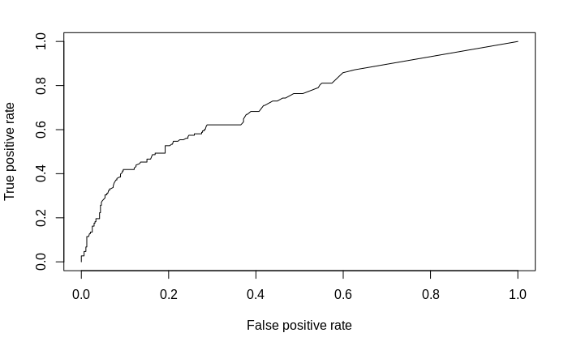

```r
perf_roc = performance(pred, "tpr","fpr")
plot(perf_roc)
```